# Evolutionary Genomics and Bioinformatics

Margaret Hilliard

Fall 2020

## lab reports:

> - Lab 1 : Introduction to R and Reproducible Research
> - Lab 2 : git, GitHub and Rstudio projects
> - Lab 3A : Data Wrangling Part 1 - Starting with the Data
> - Lab 3B : Data Wrangling Part 2 - Manipulating Data
> - Lab 4 : Data wrangling and graphing COVID-19 reporting data (Part 1)
> - Lab 4A: Data visualization with ggplot2
> - Lab 5 : Data wrangling and graphing COVID-19 reporting data (Part 2)
> - Lab 5A: Interactive Graphs and Animations from the COVID-19 reporting data
> - Lab 6 : Data Maps and Interactive Graphs from the COVID-19 reporting data
> - Lab 7: RNA-Seq workflow: gene-level exploratory analysis and differential expression
> - Lab 8: Sequence Alignment, Phylogenetic Analysis and Tree Visualization
> - Lab 9: Programming in R - Regular Expressions
> - Lab 9A: Programming in R - Control Structures and Functions
> - Lab 10: Population genomics based on high throughput sequencing (HTS)
> - Lab 11: Microbiome Analysis using dada2 and phyloseq
> - Lab 11A: Microbiome Analysis using phyloseq
> - Lab 12: Network Analysis using Cytoscape and RCy3

## dog tax:

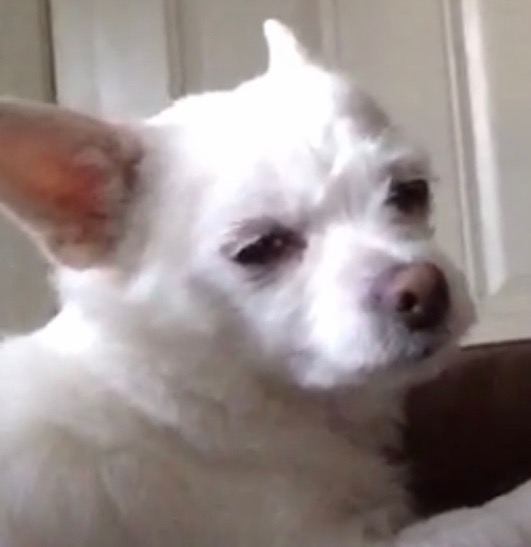

this is Skippy

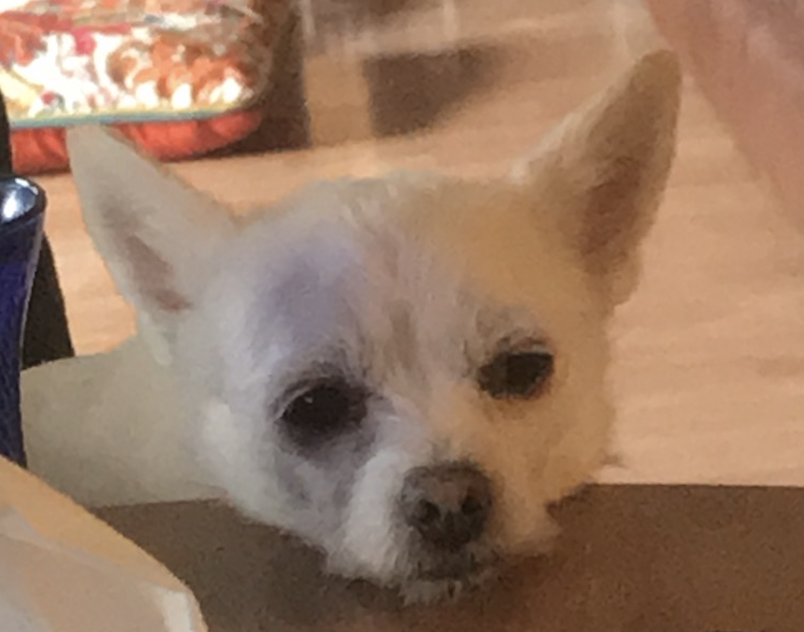

she’s a chihuahua mix

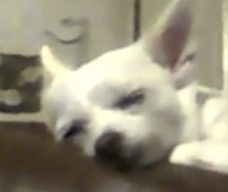

taking a tiny nap